# Exploratory Data Analysis

Tristan Shah

2/4/2022

## Packages

```r
library(tidyverse)
library(patchwork)
```

## Data

The data set I have chosen for this EDA is ChickWeight. It is a four column tabular data set containing 578 data points. This data was created by measuring the weight of newborn chicks every other day from their birth to 20 days thereafter (and on day 21). Different diets were supplied to groups of chicks to measure the respective weight change.

```r
data("ChickWeight")

## Converting data to tibble and setting columns to integers
ChickWeight %>%
  tibble %>%
  mutate_all(as.integer) -> chick_data

## Display the data
head(chick_data)
```

```
## # A tibble: 6 × 4
##   weight  Time Chick  Diet
##    <int> <int> <int> <int>
## 1     42     0    15     1
## 2     51     2    15     1
## 3     59     4    15     1
## 4     64     6    15     1
## 5     76     8    15     1
## 6     93    10    15     1
```

## Questions:

1.) Is there a complete sequence of weights for each chicken of 21 days?

2.) Are there an equal number of datapoints for each diet?

3.) Is there a difference in weight gain on average for each feed type?

4.) What is the distribution of starting chick weights? What is the distribution of end chick weights?

### Is there a complete sequence of weights for each chicken of 21 days?

In order to answer this question we need to group the data by chick number and visualize the number of days that it has been on its diet since birth. If we see chicks which did not complete the experiment they must be removed.

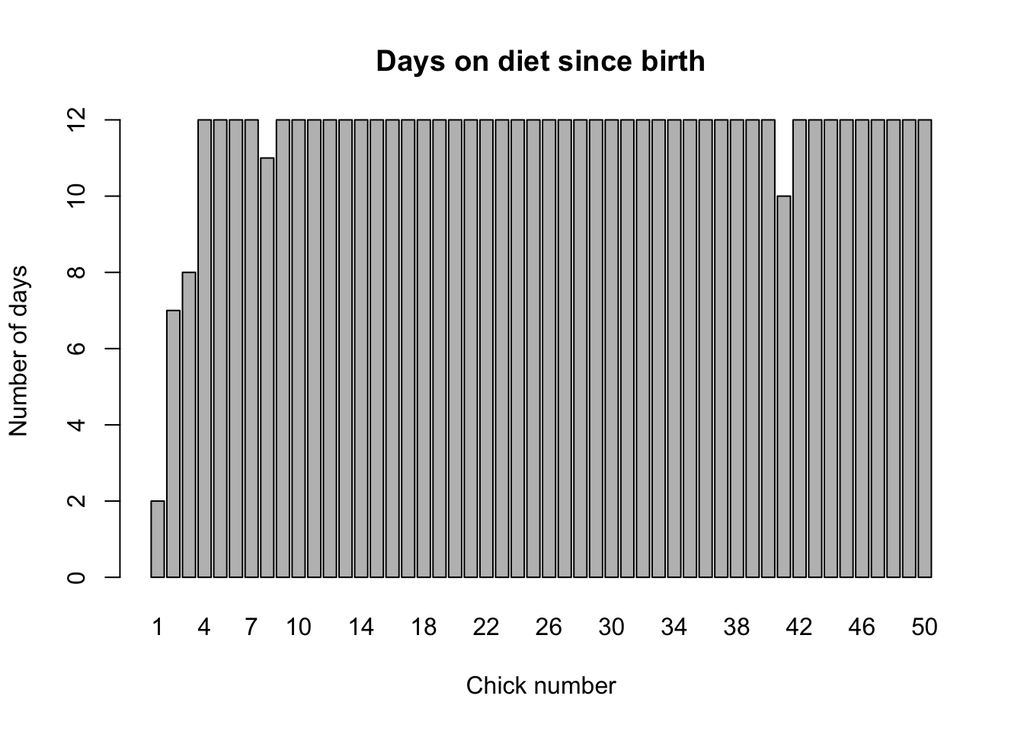

```r
chick_data %>%
  group_by(Chick) %>%
  summarise(num_days = length(Time)) -> num_days_by_chick

barplot(
  height = num_days_by_chick$num_days,
  names.arg = num_days_by_chick$Chick,
  xlab = "Chick number",
  ylab = "Number of days",
  main = "Days on diet since birth")
```

We can see that several of the chicks have not completed the experiment. We will use a filter function to remove those chicks from the data set.

```r
chick_data %>%
  group_by(Chick) %>%
  filter(length(Time) == max(num_days_by_chick$num_days)) %>%
  ungroup() -> chick_data
```

Now that we have determined that not all chicks have completed the experiment and filtered those out of the data set we can proceed with the next question.

### Are there an equal number of datapoints for each diet?

We can grup by diet and measure the length of an attribute in the table.

```r
chick_data %>%
  group_by(Diet) %>%
  summarise(num_chicks = length(Chick))
```

```
## # A tibble: 4 × 2
##    Diet num_chicks
##   <int>      <int>
## 1     1        192
## 2     2        120
## 3     3        120
## 4     4        108
```

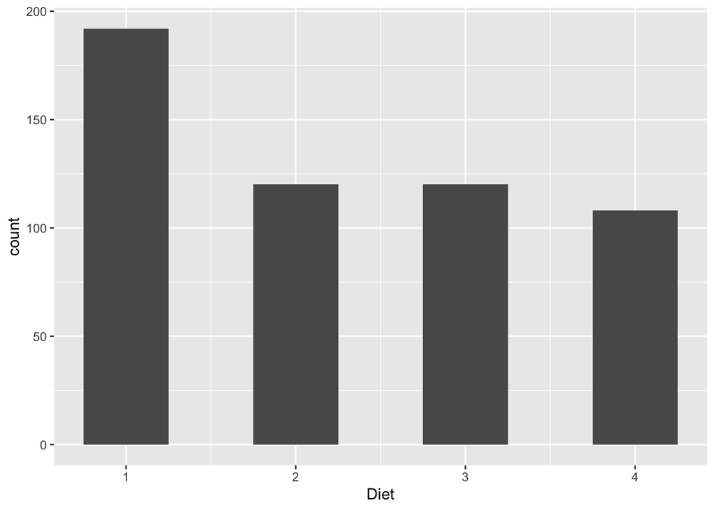

```r
ggplot(chick_data, aes(x = Diet)) + geom_histogram(bins = 4, binwidth = 0.5)
```

This bar plot highlights the large number of samples for Diet #1. While the rest of the diets have a similar number of data points. In future analysis we can utilize this knowledge to include confidence bands based on the sample size for plotting weight.

### Is there a difference in weight gain on average for each feed type?

In order to answer this question we must find the average weight of chicks for each feed type per day. We will group by Diet and day, then take the average of the chick weights and store it in a new variable.

```r
chick_data %>%
  group_by(Diet, Time) %>%
  summarise(avg_chick_weight = mean(weight)) -> avg_chick_weight_by_diet
avg_chick_weight_by_diet
```

```
## # A tibble: 48 × 3
## # Groups:   Diet [4]
##     Diet  Time avg_chick_weight
##    <int> <int>            <dbl>
##  1     1     0             41.6
##  2     1     2             47.9
##  3     1     4             56.7
##  4     1     6             67.7
##  5     1     8             81.6
##  6     1    10             97.2
##  7     1    12            114.
##  8     1    14            127.
##  9     1    16            146.
## 10     1    18            160.
## # … with 38 more rows
```

The average weight looks to be increasing for each Diet type. We will now create a scatter plot of the says (x axis) vs the average weight of the chicks. Color will be used to differentiate the feed types.

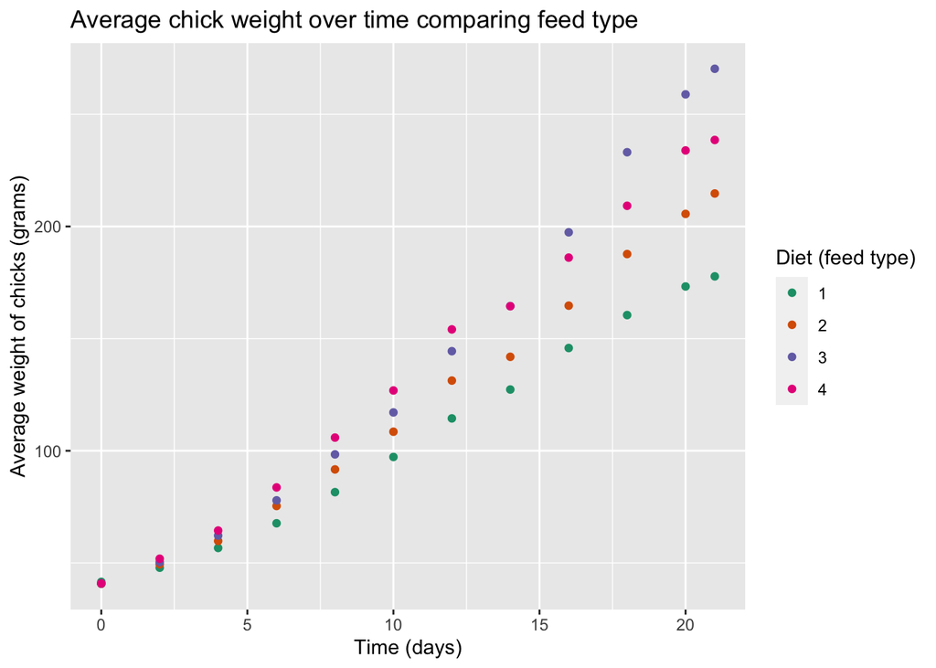

```r
## Creating plot
ggplot(
  data = avg_chick_weight_by_diet,
  mapping = aes(
    x = Time,
    y = avg_chick_weight,
    color = as.factor(Diet))) -> avg_chick_weight_plot

## Styling plot
avg_chick_weight_plot +
  geom_point() +
  labs(
    x = "Time (days)",
    y = "Average weight of chicks (grams)",
    color = "Diet (feed type)",
    title = "Average chick weight over time comparing feed type") +
  scale_color_brewer(palette = "Dark2")
```

### What is the distribution of starting chick weights? What is the distribution of end chick weights?

To answer this question we need two vectors. The first vector will be the starting weight of all chicks on day 0. The second vector will be the end weight of the chicks on day 21. We will compute summary statistics on these vectors and plot the results.

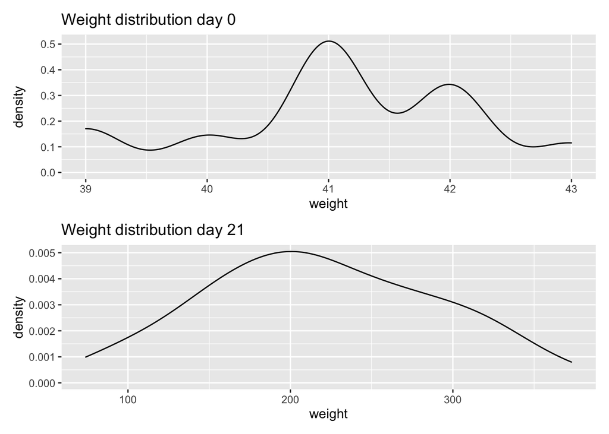

```r
chick_data %>%
  filter(Time == 0) %>%
  ggplot(aes(x=weight)) + geom_density() + labs(title = "Weight distribution day 0")-> day_0_dist

chick_data %>%
  filter(Time == 21) %>%
  ggplot(aes(x=weight)) + geom_density() + labs(title = "Weight distribution day 21") -> day_21_dist

day_0_dist / day_21_dist
```

The initial and final weight distributions are quite different in terms of overall weight as well as the shape. The distribution for the initial weight is much sharper and has a significant peak around 41 grams. The final weight distribution for day 21 spans a much larger range with a peak at 200 grams.